# Inclusion Factory Problem Description and Python Code

这个文档作为Inclusion Factory项目的内部文档，是用来说明排班系统的问题描述，解决算法，以及如何在Python中实现的，将分为四个部分：

- **背景介绍与初步思路**
- **Inclusion Factory的问题描述与数学表达**
- **解决算法与package**
- **Python代码的说明文档**

我们将在这个章节介绍Inclusion Factory的背景，以及需要考量的点。

## 背景介绍与初步思路

首先我们了解到，IF目前雇员为22名，均为有不同程度的智力与肢体障碍的人士，大部分不识字。工人在工厂中从事主要由德资车企提供的简单地拼装工作，也就是又客户向工厂提供元件，由工厂进行拼装生产后发货给客户，采取订单制管理模式，由job coach或manager进行每天的排班。主要生产的产品有十余种，每种产品可能包含多个工序，存在较为简单地生产逻辑，也就是简单地流水线式作业。例如：

- 行程开关
  - 摆螺丝
  - 组装开关
- 安全阀
  - 预放组件
  - 推安全阀
  - 检查

每一个工人每天进行四个shift的生产工作，每一个shift可以进行不同工序的生产，也可以一天内四个shift都为同一种工序生产。所以该问题可以抽象为变量为0/1的线性规划排班问题，我们将在下一个章节中给出数学表达。

## Inclusion Factory的问题描述与数学表达

我们提到，IF的诉求为在每个工人每天至多四个班次的情况下，进行科学的排班，以完成接受的订单。所以，我们可以抽象为线性规划排班问题，也就是给定一个目标函数与诸多限制条件，寻找最优的可行解。目标函数可以根据我们的需求给出，例如最小化总工时等于按照各个订单的deadline组织生产，最大化预计产出等于全产能生产等。限制条件为客观条件，例如每人每天总班次不得超过4，生产的产品数量必须大于最低要求，同一个产品的不同生产工序要保证上游产能略大于下游产能等。

所以我们将在后面逐步讨论：

- 数据与数据预处理
- 问题的数学表达
- 将来拓展

### 数据与数据预处理

**生产力数据(Worker efficiency)**

由于每个工人接受的训练不同，身体情况与精神状况的不同，导致各个工人所能生产的产品与生产效率不尽相同，下表为各个工人对于目前工厂生产的产品的生产效率，即每小时所生产的产品数量。

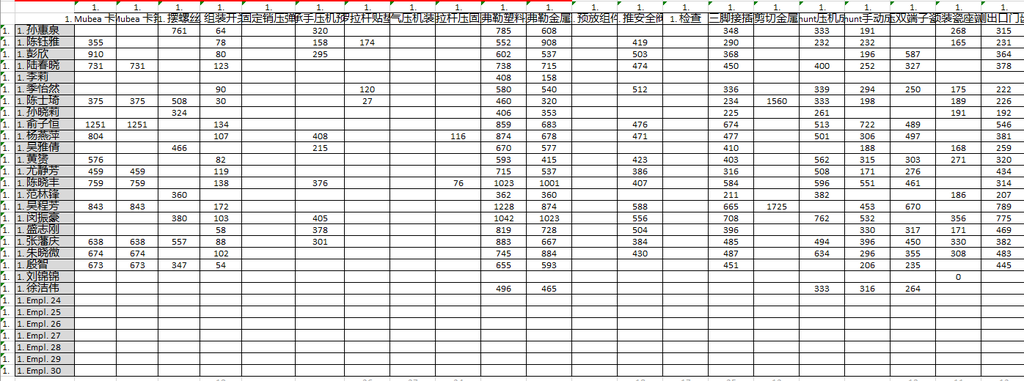

**订单数据(Order data)**

根据不同的客户与产品，我们会在订单数据中逐条添加，如下图：

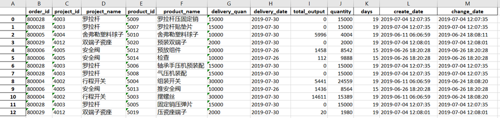

其中"delivery_date"为deadline，"total_output"为已经生产的数量，"days"为剩余时间，"quantity"代表还需生产的数量。我们用"project"代表生产的产品，"product"代表各个部件。

**生产逻辑(Procedure)**

生产逻辑包含各个可以生产的产品的生产步骤，同一个客户可能有多个产品，每个产品可能会有多个生产步骤，关系如下图所示：

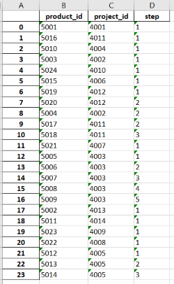

所以在规定限制条件时，我们会根据生产逻辑，保证上游步骤的生产能力略大于下游的生产能力，进而确保生产线的稳定。

### 问题的数学表达

首先我们先定义数据中的数学符号(Notation):

- $W_i$ ：工人i的ID，i的取值范围为 $0-21$，共计22名工人，最大值记为$W_{max}$
- $P_i$ ：产品工序i的ID，i的取值范围为 $0-12$，共计13种工序，最大值记为$P_{max}$
- $E_{ij}$：工人i对产品工序j的生产效率，即每小时所能生产的数量
- $D_i$ ：产品工序i的剩余工期
- $O_i$ ：产品工序i的待生产数量

以及我们输出的结果变量为：

- $V(w, s, p)$ ：类型为Boolean, 值为0/1，表示当天在岗工人$w$是否在$s$班次生产产品$p$
- $R_{low}(p)$ ：类型为Integer，表示当天产品工序$p$的预计最少数量
- $R_{up}(p)$ ：类型为Integer，表示当天产品工序$p$的生产上限数
- $EstOut(p)$ ：类型为Integer，表示当天产品工序$p$的预计生产数量

**优化目标函数**

我们还是以注重员工工作多样性的最大生产排产为例。这里是我们首先要考量的目标：

- 希望排产的产出为最大，在满足各个限制条件的情况下
- 每个工人每个班次只能生产一种产品
- 对于任意生产工序$p$，每日的预计产量不得少于$R_{low}(p)$
- 对于任意生产工序$p$，每日的预计产量不得大于$R_{up}(p)$
- 每个工人每天的劳动班次总数不得超过4
- 对于任意两个工人，当日的劳动班次总数相差不得超过1
- 上游生产工序的产能略大于下游生产工序的产能
- 每个员工当日至少从事两种以上的任务

所以，我们要最大化的目标函数为：

其中$N(p)$是当前排班下的产品工序$p$的预计总产出，目标函数代表了每个产品工序实际排产的产量超出最低生产标准的比率，通过最大化$Z$来确保我们的排产是最大化产出的排产。

**限制条件**

我们需要一些客观现实的限制条件来给出问题的可行域，也就是说我们的最优化结果是在下面的限制条件都满足的情况下的最优结果。

- **每个工人每个班次只能生产一种产品**

$\quad \ \;$因为我们的变量为$V(w, s, p)$，代表工人$w$在班次$s$是否从事生产工序$p$的生产工作，为0/1变量，所以对于任意工人$w$和班次$s$，我们有：

$$ \sum_{p = 0}^{P_{max}} V_{w,s,p} \le 1 $$

- **对于任意生产工序$p$，每日的预计产量不得少于$R_{low}(p)$**

$$ \sum_{w = 0}^{W_{max}} \sum_{s = 0}^{3} \sum_{p = 0}^{P_{max}} V_{w,s,p} \times E(w,p) \ge R_{low}(p) $$

$$ \sum_{w = 0}^{W_{max}} \sum_{s = 0}^{3} \sum_{p = 0}^{P_{max}} V_{w,s,p} \times E(w,p) \le R_{up}(p) $$

- **每个工人每天的劳动班次总数不得超过4**

$\quad \ \;$对于任意一个工人$w$，我们有：

$$ \sum_{s = 0}^{3} \sum_{p=0}^{P_{max}} V(w,s,p) \le 4 $$

- **对于任意两个工人，当日的劳动班次总数相差不得超过1**

$\quad \ \;$这里是为了保证不会出现能力较强的工人班次排满，而能力较弱的工人出现过多地"No Task"情况，对于任意两个工人$w_i$和$w_j$，我们有：

$$ | \sum_{s = 0}^{3} \sum_{p=0}^{P_{max}} V(w_i,s,p) - \sum_{s = 0}^{3} \sum_{p=0}^{P_{max}} V(w_j,s,p) | \le 1 $$

- **上游生产工序的产能略大于下游生产工序的产能**

$\quad \ \;$这里是为了保证下游的生产线不会因为上游半成品供应不足而导致停产，如果考虑半成品的历史存货，则为：对于任意一组上游产品$p_i$与下游产品$p_j$，和任意班次$s$：

$$ \frac{(O_i - O_j)}{4} + \sum_{w = 0}^{W_{max}} V_{w,s,p_i} \times E(w,p_i) \ge \sum_{w = 0}^{W_{max}} V_{w,s,p_j} \times E(w,p_j) $$

$\quad \ \;$上式的含义是指上游产品对比下游产品的绝对盈余除以一天的班次总数加上本班次生产的上游产品工序，要大于下游产品工序的产量。

- **每个员工当日至少从事两种以上的任务**

$\quad \ \;$这里是出于对员工发展的考量，希望强制每个员工从事多种不同的工作来熟悉各个类型的技能，所以对于任意工人$w$和任意产品工序$p$，我们有：

$$ \sum_{s = 0}^{3} V(w,s,p) \le 3 $$

## 解决算法与package

为了解决上面的线性规划问题，我们需要使用单纯型法，也就是著名的大M算法。而通过调用python的pulp包裹，我们可以定义自己的线性规划问题，并进行快速求解。对于pulp包裹的详细介绍见：https://pythonhosted.org/PuLP/

简言之，pulp的使用步骤包括：

- 相关包裹载入
- 数据的读取（HANA数据库或包含json文件的service）
- 数据预处理
- 定义线性规划目标函数与限制条件
- 求解问题并转换输出结果
- 存储结果（insert至数据库或process save）

## Python代码的说明文档（本地HANA版）

下面我们将按照pulp的使用步骤来逐步解释代码

- **相关包裹载入**

```python
import logging
from flask import Flask
from flask_cors import CORS
from flask import render_template
import pyhdb
import pulp
#import xlrd
import numpy as np
import math
from math import isnan
import json
import pandas as pd
import time
import copy

application = Flask(__name__)
CORS(application)
```

```
<flask_cors.extension.CORS at 0x1cd392194e0>
```

其中pyhdb用于python与HANA数据库的连接；pulp为线性规划求解包裹；其余的为数据处理的基本包裹。

- **数据的读取（HANA数据库）**

在本地版解决方案中，我们使用"pyhdb"来进行python与HANA数据库的连接，使用时只需修改host, port, user, password以及相应的sql语句。

```python
def get_connection():
    conn = pyhdb.connect(host = "##.##.##.###", #HANA地址
                         port = "#####", #HANA端口号
                         user = "I######", #用户名
                         password = "########") #密码
    return conn

def get_efficiency(conn): #有可能用worker output那张表来解决
    cursor = conn.cursor()
    cursor.execute('Select * from "IFACTORY"."IFactory.Data::table.WORKER_OUTPUT_V" where "WORKER_ID" in (Select "WORKER_ID" from "IFACTORY"."IFactory.Data::table.WORKER_DETAIL");',{})
    mat = cursor.fetchall()
    mat = pd.DataFrame(mat)#从数据库中存储efficiency，做成df是为了方便管理
    try:
        cursor.close()
    except:
        pass
    return mat
# where "WORKER_ID" in (Select "WORKER_ID" from "IFACTORY"."IFactory.Data::table.WORKER_DETAIL")



def get_order(conn):
    cursor = conn.cursor()
    cursor.execute('SELECT * FROM "IFACTORY"."IFactory.Data::table.ORDER_PLAN_V";',{})
    mat = cursor.fetchall()
    mat = pd.DataFrame(mat)#存储order信息，同上
    try:
        cursor.close()
    except:
        pass
    return mat

def get_procedure(conn):
    cursor = conn.cursor()
    cursor.execute('SELECT * FROM "IFACTORY"."IFactory.Data::table.PROJECT_PRODUCT";',{})
    mat = cursor.fetchall()
    mat = pd.DataFrame(mat)#存储order信息，同上
    try:
        cursor.close()
    except:
        pass
    return mat

def delete_shift_result(conn):
     try: ##这里有可能会出现插入不成功的情况，可能会由于数据库关闭，或者运算出来的数据有问题，也就是不能满足订单的需求
        cursor = conn.cursor()
        cursor.execute('DELETE FROM "IFACTORY"."IFactory.Data::table.SHIFT_RESULT"', {})
        cursor.close() #记得要随时close，防止出现别处无法访问的情况
        return "history shift data removed successfully." #记得要commit，不然sql语句无法实行，之后close connection
     except:
        return "failed to remove history shift data."

def insert_res1(conn,json_res):
    try: ##这里有可能会出现插入不成功的情况，可能会由于数据库关闭，或者运算出来的数据有问题，也就是不能满足订单的需求
        cursor = conn.cursor()
        cursor.execute('INSERT INTO "IFACTORY"."IFactory.Data::table.SHIFT_RESULT" values(\'' +time.asctime( time.localtime(time.time()))
        +'\',\'Fastest\',\'' + json_res + '\' ) ;', {})
        cursor.close() #记得要随时close，防止出现别处无法访问的情况
        return "schedule 1 inserted successfully"
    except:
        return "schedule 1 failed to insert"

def insert_res2(conn,json_res):
    try: ##这里有可能会出现插入不成功的情况，可能会由于数据库关闭，或者运算出来的数据有问题，也就是不能满足订单的需求
        cursor = conn.cursor()
        cursor.execute('INSERT INTO "IFACTORY"."IFactory.Data::table.SHIFT_RESULT" values(\'' +time.asctime( time.localtime(time.time()))
        +'\',\'MaxOutput\',\'' + json_res + '\' ) ;', {})
        cursor.close() #记得要随时close，防止出现别处无法访问的情况
        return "schedule 2 inserted successfully" #记得要commit，不然sql语句无法实行，之后close connection
    except:
        return "schedule 2 failed to insert"

def insert_res3(conn,json_res):
     try:
        cursor = conn.cursor()
        cursor.execute('INSERT INTO "IFACTORY"."IFactory.Data::table.SHIFT_RESULT" values(\'' +time.asctime( time.localtime(time.time()))
        +'\',\'Diversity\',\'' + json_res + '\' ) ;', {})
        cursor.close()
        return "schedule 3 inserted successfully"
     except:
        return "schedule 3 failed to insert"
```

其中：

- *get_connection()* 用于建立数据库连接
- *get_efficiency(conn)*, *get_order(conn)*, 与*get_procedure(conn)* 用于获取Worker_efficiency, Order, 与 procedure
- *delete_shift_result(conn)* 用于清空之前的排班结果
- *insert_res1(conn,json_res)* 用于插入新的计算结果

**数据预处理**

```python
def lower_bound(order,j): #计算某种产品的最低产量要求,这里order是dataframe，而j是product id字符串
    #product_name = "Product" + str.upper(j) #因为数据库中的名字是ProductA之类的
    order_j = []
    for i in range(len(order)):
        if order["product_id"][i] == j:
            order_j.append([order["quantity"][i],order["days"][i]])
    low = 0
    for i in order_j:
        if (float(i[0]) != 0) & (float(i[1]) != 0):
            low += float(i[0])/float(i[1])
    return low

def upper_bound(order,j):
    #product_name = "Product" + str.upper(j) #因为数据库中的名字是ProductA之类的
    order_j = []
    for i in range(len(order)):
        if order["product_id"][i] == j:
            order_j.append([order["quantity"][i],order["days"][i]])
    up = 0
    for i in order_j :
        if (float(i[0]) != 0) & (float(i[1]) != 0):
            up += 30*float(i[0])/float(i[1]) #四倍是较为合理的，如果一天预计产能超过了10倍，就会对原材料造成影响
    return up


def problem_des():
    conn = get_connection()
    efficiency = get_efficiency(conn) #注意数据结构，需要更改
    eff = pd.DataFrame(efficiency,index = list(map(int,np.linspace(0,len(efficiency),len(efficiency),endpoint = False).tolist())))
    eff.columns = ["worker_id","project_id","product_id","date","output"]
    order = get_order(conn)
    order.index = list(map(int,np.linspace(0,len(order),len(order),endpoint = False).tolist()))
    order.columns = ["order_id","project_id","project_name","product_id","product_name","delivery_quan","delivery_date","total_output","quantity","days","create_date","change_date"]
    #需要注意在order中可能出现天数为0的情况，需要判断一下然后改成1
    order = order.dropna(axis = 0, how = "any") #防止出现nan在order中，导致问题
    for i in range(0,len(order["days"])):
        if int(order["days"][i]) <= 0:
            order["days"][i] = 1
        else:
            pass


    m_num = len(eff["worker_id"].drop_duplicates(keep = "first"))
    n_num = len(order["product_id"].drop_duplicates(keep = "first"))
    s_num = 4 #每天有四个shift，当然也可以有所改变，但那样也会导致单个shift时间增长
    worker = sorted(eff["worker_id"].drop_duplicates(keep = "first"))
    product = sorted(order["product_id"].drop_duplicates(keep = "first"))
    worker_efficiency = np.zeros([m_num,n_num],dtype = np.float)  #后续把他改成用最近20次的
    for i in range(m_num):
        for j in range(n_num):
            worker_i = eff[eff["worker_id"] == worker[i]]
            mean = np.mean(list(map(float,worker_i[worker_i["product_id"] == product[j]]["output"].tolist())))
            worker_efficiency[i][j] = mean
    #有可能会出现因为数据不存在而导致的nan出现，故将nan替换为0，也就是默认该工人不会此种工作
    for i in range(m_num):
        for j in range(n_num):
            if isnan(worker_efficiency[i,j]) == True:
                worker_efficiency[i,j] = 0
            else:
                pass

    procedure = get_procedure(conn)
    procedure.columns = ["product_id","project_id","step"]
    project = order["project_id"].drop_duplicates(keep = "first")
    #shift_length?


    return worker_efficiency,order,m_num,n_num,s_num,worker,product,procedure,project
```

其中：

- *lower_bound(order,j)* 与 *upper_bound(order,j)*用来计算每种产品工序当日生产的上下限
- *problem_des()* 用来整理出pulp构建线性规划问题的数据形式，包含worker_efficiency,order,m_num,n_num,s_num,worker,product,procedure,project变量

**定义线性规划目标函数与限制条件**

接下来，因为我们得到了pulp所需的数据，我们将在*init()*函数中定义目标函数与限制条件

```python
#地三种排班方式，在完成当日最低产量的前提下，让每个工人在一天内都至少进行两种不同的工作
def init3(worker_efficiency,order,m_num,n_num,s_num,worker,product,procedure,project):
    ###问题定义
    #变量
    variables = np.array([pulp.LpVariable('x%d_%d_%d'%(i,j,k), lowBound = 0, upBound = 1,cat = pulp.LpInteger)
    for i in range(0, m_num) for j in range(0, s_num)  for k in range(0,n_num)]) #每个工人每天至多4个shift

    #目标函数
    z = sum(np.random.randint(1,2,m_num*s_num*n_num) * variables)

    #约束条件
    constraints = [] #用来存储限制条件
    res = [] #用来记录每个工人的总班次

    #约束条件0 每人每个shift只能有一项工作
    for j in range(s_num):
        for i in range(m_num):
            a = np.zeros([m_num,s_num,n_num])
            for k in range(n_num):
                a[i,j,k] = 1
            constraint_k = sum(a.flatten()*variables) <= 1
            constraints.append(constraint_k)


    #约束条件0.1 每一个人工作尽量向前放
    for j in range(s_num-1):
        for i in range(m_num):
            a = np.zeros([m_num,s_num,n_num])
            b = np.zeros([m_num,s_num,n_num])
            for k in range(n_num):
                a[i,j,k] = 1
                b[i,j+1,k] = 1
            constraint_k = sum(a.flatten()*variables) >= sum(b.flatten()*variables)
            constraints.append(constraint_k)

    #约束条件1 保证当日所有产品的产量超过最低要求
    for k in range(n_num):
        low = lower_bound(order,product[k])
        ek = [] #工人生产产品j的效率
        for i in range(m_num):
            ek.append(worker_efficiency[i][k])
        a = np.zeros([m_num,s_num,n_num])
        for i in range(m_num):
            for j in range(s_num):
                a[i,j,k] = ek[i]
        constraint_k = 2*sum(a.flatten()*variables) >= low
        constraints.append(constraint_k)

    #约束条件2 保证当日所有的商品产量不超过我们设置的上限
    for k in range(n_num):
        up = upper_bound(order,product[k])
        if up >= 500:
            ek = [] #工人生产产品j的效率
            for i in range(m_num):
                ek.append(worker_efficiency[i][k])
            a = np.zeros([m_num,s_num,n_num])
            for i in range(m_num):
                for j in range(s_num):
                    a[i,j,k] = ek[i]
            constraint_k = 2*sum(a.flatten()*variables) <= up
            constraints.append(constraint_k)
        else:
            ek = [] #工人生产产品j的效率
            for i in range(m_num):
                ek.append(worker_efficiency[i][k])
            a = np.zeros([m_num,s_num,n_num])
            for i in range(m_num):
                for j in range(s_num):
                    a[i,j,k] = ek[i]
            constraint_k = 2*sum(a.flatten()*variables) <= 500
            constraints.append(constraint_k)

    #约束条件3 每个工人每天的shift总数不得超过4
    for i in range(m_num):
        a = np.zeros([m_num,s_num,n_num])
        for j in range(s_num):
            for k in range(n_num):
                a[i,j,k] = 1
        res.append(sum(a.flatten()*variables))
        constraint_k = sum(a.flatten()*variables) <= 4
        constraints.append(constraint_k)

    #约束条件4 每个工人工作的shift总数不会相差超过1
    for i in range(m_num):
        for j in range(i+1,m_num):
            constraint_i = (res[i] - res[j]) >= -1
            constraints.append(constraint_i)
            constraint_i = (res[i] - res[j]) <= 1
            constraints.append(constraint_i)

    #约束条件5 保证在每一个shift，每个工序有足够的工人工作，先头工序的产能略大于后续的产能
    #我们先以字典形式储存各个shift的各个产品的产能
    shift1 = {}
    shift2 = {}
    shift3 = {}
    shift4 = {}
    for k in range(n_num):
        ek = [] #工人生产产品k的效率
        for i in range(m_num):
            ek.append(worker_efficiency[i][k])
        a = np.zeros([m_num,s_num,n_num])
        j = 0
        for i in range(m_num):
            a[i,j,k] = ek[i]
        shift1[product[k]] = sum(a.flatten()*variables)
    for k in range(n_num):
        ek = [] #工人生产产品k的效率
        for i in range(m_num):
            ek.append(worker_efficiency[i][k])
        a = np.zeros([m_num,s_num,n_num])
        j = 0
        for i in range(m_num):
            a[i,j,k] = ek[i]
        shift2[product[k]] = sum(a.flatten()*variables)
    for k in range(n_num):
        ek = [] #工人生产产品k的效率
        for i in range(m_num):
            ek.append(worker_efficiency[i][k])
        a = np.zeros([m_num,s_num,n_num])
        j = 0
        for i in range(m_num):
            a[i,j,k] = ek[i]
        shift3[product[k]] = sum(a.flatten()*variables)
    for k in range(n_num):
        ek = [] #工人生产产品k的效率
        for i in range(m_num):
            ek.append(worker_efficiency[i][k])
        a = np.zeros([m_num,s_num,n_num])
        j = 0
        for i in range(m_num):
            a[i,j,k] = ek[i]
        shift4[product[k]] = sum(a.flatten()*variables)

    #然后根据定义的procedure找出各个project的工序，并加入限制条件
    for p in project:
        procedure_p = procedure[procedure["project_id"]==p]
        for i in range(len(procedure_p)-1):
            product_1 = list(procedure_p[procedure_p["step"] == str(i+1)]["product_id"])
            product_2 = list(procedure_p[procedure_p["step"] == str(i+2)]["product_id"])
            for j in product_1:
                for k in product_2:
                    order_j = order[(order["product_id"] == j) & (order["project_id"] == p)]
                    order_k = order[(order["product_id"] == k) & (order["project_id"] == p)]
                    exceed_output = (sum(list(order_j["total_output"])) - sum(list(order_k["total_output"])))/4
                    constraint_k = shift1[j] + exceed_output >= shift1[k]
                    constraints.append(constraint_k)

    for p in project:
        procedure_p = procedure[procedure["project_id"]==p]
        for i in range(len(procedure_p)-1):
            product_1 = list(procedure_p[procedure_p["step"] == str(i+1)]["product_id"])
            product_2 = list(procedure_p[procedure_p["step"] == str(i+2)]["product_id"])
            for j in product_1:
                for k in product_2:
                    order_j = order[(order["product_id"] == j) & (order["project_id"] == p)]
                    order_k = order[(order["product_id"] == k) & (order["project_id"] == p)]
                    exceed_output = (sum(list(order_j["total_output"])) - sum(list(order_k["total_output"])))/4
                    constraint_k = shift2[j] + exceed_output >= shift2[k]
                    constraints.append(constraint_k)

    for p in project:
        procedure_p = procedure[procedure["project_id"]==p]
        for i in range(len(procedure_p)-1):
            product_1 = list(procedure_p[procedure_p["step"] == str(i+1)]["product_id"])
            product_2 = list(procedure_p[procedure_p["step"] == str(i+2)]["product_id"])
            for j in product_1:
                for k in product_2:
                    order_j = order[(order["product_id"] == j) & (order["project_id"] == p)]
                    order_k = order[(order["product_id"] == k) & (order["project_id"] == p)]
                    exceed_output = (sum(list(order_j["total_output"])) - sum(list(order_k["total_output"])))/4
                    constraint_k = shift3[j] + exceed_output >= shift3[k]
                    constraints.append(constraint_k)

    for p in project:
        procedure_p = procedure[procedure["project_id"]==p]
        for i in range(len(procedure_p)-1):
            product_1 = list(procedure_p[procedure_p["step"] == str(i+1)]["product_id"])
            product_2 = list(procedure_p[procedure_p["step"] == str(i+2)]["product_id"])
            for j in product_1:
                for k in product_2:
                    order_j = order[(order["product_id"] == j) & (order["project_id"] == p)]
                    order_k = order[(order["product_id"] == k) & (order["project_id"] == p)]
                    exceed_output = (sum(list(order_j["total_output"])) - sum(list(order_k["total_output"])))/4
                    constraint_k = shift4[j] + exceed_output >= shift4[k]
                    constraints.append(constraint_k)

    ##约束条件6 每一个工人每天至少从事两种以上的工作，也就是指每一个工作每天不超过3个shift，即便如此会出现3个一样工作+1个空闲，也不为被我们的初始愿望
    for i in range(m_num):
        for k in range(n_num):
            a = np.zeros([m_num,s_num,n_num])
            for j in range(s_num):
                a[i,j,k] = 1
            constraint_k = sum(a.flatten()*variables) <=3
            constraints.append(constraint_k)

    return z,constraints
```

**求解问题并转换输出结果**

因为我们希望得到在给定限制条件下最大的生产产出，故需要在*solve_ilp3()*函数中使用*pulp.LpMaximize*方法来得到最大值。

*result_trans()*函数用来计算给定的排班计划相应的预计产出，working_load，以及预计完成时间。

```python
#第三种排班方式的求解函数
def solve_ilp3(z, constraints):
    """
    求解问题
    """
    prob = pulp.LpProblem('LP', pulp.LpMaximize)
    prob += z
    for cons in constraints:
        prob += cons
    #print(prob)
    status = prob.solve()
    if status != 1:
        return None
    else:
        return [[v,v.varValue.real] for v in prob.variables()]

def result_trans(res, m_num, n_num, s_num, worker_efficiency, product, worker,order):
    wh = np.zeros([m_num,s_num,n_num])
    for v in res:
        wh[int(str(v[0]).replace('x','').split('_')[0])][int(str(v[0]).replace('x','').split('_')[1])][int(str(v[0]).replace('x','').split('_')[2])]= v[1]
    # wh = np.array(res).reshape(m_num,n_num)
    hpp = np.zeros([m_num,n_num]) #每一行代表每个工人当日在每个comp上的shift总数
    for i in range(m_num):
        hpp[i] = wh[i].sum(axis = 0)
    hpps = hpp.sum(axis = 1) #每个元素代表每个工人当日的总shift数
    worker_output = np.zeros([m_num,n_num])
    for i in range(m_num):
        worker_output[i] = hpp[i]*np.array(worker_efficiency[i])*2
    producted = worker_output.sum(axis = 0)
    low = np.zeros(n_num)
    for i in range(n_num):
        low[i]  = math.floor(lower_bound(order,product[i]))
    up = np.zeros(n_num)
    for i in range(n_num):
        up[i] = math.ceil(upper_bound(order,product[i]))
    res2 = pd.DataFrame(res, columns = ["var","value"])
    output = {}
    for i in worker:
        index = np.argwhere(np.array(worker) == i).tolist()[0][0]
        seq = np.arange(index*s_num*n_num,(index+1)*s_num*n_num) #该工人的当天变量
        temp = []
        for j in range(s_num):
            temp1 = seq[np.arange(j*n_num,(j+1)*n_num)]
            temp2 = (res2["value"][temp1]).tolist()
            temp.append(temp2)
        output[i] = copy.deepcopy(temp)

    output2 = np.zeros([m_num,s_num]).tolist()
    for i in range(len(output)):
        for j in range(len(output[list(output.keys())[i]])):
            if len(np.argwhere(np.array(output[list(output.keys())[i]][j]) == 1)) == 0:
                pass
            else:
                a = np.argwhere(np.array(output[list(output.keys())[i]][j]) == 1)[0][0]
                output2[i][j] = product[a]

    output3 = copy.deepcopy(output)
    for i in range(len(output3)):
        output3[list(output3.keys())[i]] = output2[i]
    estimated_output = {}
    for i in range(len(product)):
        estimated_output[product[i]] = producted[i]

    #estimated_duration = {}
    #for i in range(len(product)):
    #    if sum(list(order[order["product_id"] == product[i]]["quantity"])) > 0:
    #        estimated_duration[product[i]] = math.ceil(sum(list(order[order["product_id"] == product[i]]["quantity"]))/estimated_output[product[i]])
    #    else:
    #        estimated_duration[product[i]] = 0
    order_id = order["order_id"].drop_duplicates(keep = "first")
    estimated_duration = {}
    for i in order_id:
        order_i = order[order["order_id"] == i]
        order_i_duration = 0
        for j in range(len(order_i)):
            pro_temp = list(order_i["product_id"])[j]
            a = float(list(order_i["quantity"])[j])/estimated_output[pro_temp]
            if (a != np.inf) & (a > 0):
                order_i_duration = max(order_i_duration, math.ceil(a))
            else:
                pass
        if order_i_duration >= 99999:
            order_i_duration = "Infinity"
        estimated_duration[i] = order_i_duration
    real_output = json.dumps({"assignment":output3,"estimated output":estimated_output,"total shifts":hpps.sum(),
                               "working load":float('%.2f' % (100*hpps.sum()/(4*m_num))),"estimated duration":estimated_duration})
    return real_output
```

**存储结果（insert至数据库或process save）**

我们将得到的json字符串上传至指定的table。需要先删除表中之前的结果，后逐步存储数据。

```python
#@application.route('/')
def connHXE():
    worker_efficiency,order,m_num,n_num,s_num,worker,product,procedure,project = problem_des()
    z3,constraints3 = init3(worker_efficiency,order,m_num,n_num,s_num,worker,product,procedure,project)
    res3 = solve_ilp3(z3, constraints3)
    if res3 != None:
        real_output3 = result_trans(res3, m_num, n_num, s_num, worker_efficiency, product, worker, order)
    else:
        order_id = order["order_id"].drop_duplicates(keep = "first")
        estimated_duration = {}
        estimated_output_temp = {}
        for i in range(n_num):
            estimated_output_temp[product[i]] = sum(worker_efficiency[:,i])*(4/len(order_id))

        for i in order_id:
            order_i = order[order["order_id"] == i]
            order_i_duration = 0
            for j in range(len(order_i)):
                pro_temp = list(order_i["product_id"])[j]
                a = float(list(order_i["quantity"])[j])/estimated_output_temp[pro_temp]
                if (a != np.inf) & (a > 0):
                    order_i_duration = max(order_i_duration, math.ceil(a))
                else:
                    pass
            if order_i_duration >= 99999:
                order_i_duration = "Infinity"
            estimated_duration[i] = order_i_duration
        real_output3 = json.dumps({"assignment":"No feasible solution","estimated duration":estimated_duration})

    conn = get_connection()
    remove_0 = delete_shift_result(conn)
    res_1 = insert_res1(conn,real_output1)
    res_2 = insert_res2(conn,real_output2)
    res_3 = insert_res3(conn,real_output3)
    #res = json.dumps([remove_0,res_1,res_2,res_3])
    conn.commit()
    try:
        conn.close()
    except:
        pass

    return json.dumps([remove_0,res_1,res_2,res_3])
    #return json.dumps([a,b,c])


#@application.errorhandler(500)
#def server_error(e):
#    #log the error and stacktrace
#    logging.exception ('An error occurred during a request.')
#    return 'An internal error occurred.', 500
#
##run the app.
#if __name__ == "__main__":
#    application.run(host='127.0.0.1', port =8080, debug=True)
##[END application]
```

我们在下面展示一下上传的json文件

```python
print({"assignment": {"1001": ["5020", "5014", "5020", "5006"], "1002": ["5005", "5003", "5009", "5009"], "1003": ["5020", "5010", "5020", "5012"], "1004": ["5019", "5007", "5012", "5008"], "1005": ["5005", "5005", "5020", "5003"], "1006": ["5004", "5020", "5004", "5012"], "1007": ["5005", "5005", "5012", "5004"], "1008": ["5008", "5013", "5010", "5009"], "1009": ["5019", "5007", "5014", "5005"], "1010": ["5019", "5003", "5008", "5009"], "1011": ["5020", "5009", "5009", "5014"], "1012": ["5008", "5013", "5012", "5012"], "1013": ["5003", "5013", "5019", "5010"], "1014": ["5006", "5009", "5013", "5019"], "1015": ["5010", "5019", "5003", "5008"], "1016": ["5019", "5010", "5005", "5012"], "1017": ["5008", "5008", "5008", "5020"], "1018": ["5019", "5020", "5003", "5014"], "1019": ["5014", "5014", "5010", "5013"], "1020": ["5004", "5014", "5005", "5013"], "1021": ["5005", "5013", "5014", "5005"], "1022": ["5009", "5013", "5009", "5004"]}, "estimated output": {"5003": 2938.8, "5004": 1333.3333333333333, "5005": 2775.0, "5006": 3360.0, "5007": 1200.0, "5008": 2100.0, "5009": 2640.0, "5010": 3905.714285714286, "5012": 2590.0, "5013": 3205.6000000000004, "5014": 900.0, "5019": 320.0, "5020": 1200.0}, "total shifts": 88.0, "working load": 100.0, "estimated duration": {"800004": 19, "800028": 13, "800029": 7, "800005": 2, "800006": 11}})
```

```
{'assignment': {'1001': ['5020', '5014', '5020', '5006'], '1002': ['5005', '5003', '5009', '5009'], '1003': ['5020', '5010', '5020', '5012'], '1004': ['5019', '5007', '5012', '5008'], '1005': ['5005', '5005', '5020', '5003'], '1006': ['5004', '5020', '5004', '5012'], '1007': ['5005', '5005', '5012',…
```

其中包含了排班结果，预计产出，working load和预计完成时间。